# Multiple Regression Formative Exercise

L3 Teaching Team

# Analysis of STARS data: Background

For this next set of formative exercises, you’re going to be working with some real data collected about students from a previous year of students in statistics at the University of Glasgow. The data have been anonymized, and includes no demographic or other sensitive information. Each student is identified by a unique value of the variable `id`.

Students were given the STats Anxiety Rating Scale (STARS), a 51-item questionnaire which measures student’s attitudes toward statistics (Cruise, Cash, & Bolton, 1985). In each item, students are asked to rate either agreement with a statement on a 1 to 5 scale (1 = strongly disagree, 5 = strongly agree), or rate how anxious they would feel on a 1 to 5 scale (1 = no anxiety, 5 = strong anxiety). Higher numbers mean more anxiety or more negative attitudes toward statistics.

There are some additional files that you’ll need to download in order to do the task.

If you’re interested, you can see the individual survey items in the accompanying file `stars-items.pdf`.

The rating data is in the file `stars.csv`.

The STARS items can be divided up into six different subscales (Hanna, Shevlin, & Dempster, 2008). The subscales and the mapping of items to subscales is given in the file `subscales.csv`.

Your task is to use multiple regression examine the relationship between the stats anxiety subscales and overall performance in the class, as measured by the students’ final grades, which are in the file `grades.csv`.

Write solution code in the chunks provided for each task.

## Task 1: Import the data

You will need to use the **`tidyverse`** package as well as the **`corrr`** package. Load in those packages as well as `stars.csv`, `grades.csv`, and `subscales.csv`. You might want to look at the [Data Import Cheat Sheet](https://raw.githubusercontent.com/rstudio/cheatsheets/main/data-import.pdf).

```r
library("corrr")
library("tidyverse")

stars <- read_csv("stars.csv",
                  col_types = cols(.default = col_integer()))

grades <- read_csv("grades.csv", col_types = "ii")

subscales <- read_csv("subscales.csv", col_types = "cc")
```

## Task 2: Calculate subscale means

Calculate the mean score for each subscale for each student. Store the resulting table in `subscale_means`.

```r
# what should the final table look like?
# id   subscale       mean_score
#  3   Ask_For_Help   2.2
#  3   Interpretation 1.7 ... etc

stars_long <- stars |>
  pivot_longer(-id, names_to = "item_id",
               values_to = "score")

subscale_means <- stars_long |>
  inner_join(subscales,
             join_by(item_id)) |>
  group_by(id, subscale) |>
  summarise(mean_score = mean(score, na.rm = TRUE),
            .groups = "drop")
```

## Task 3: Create a correlation matrix

Create a correlation matrix using `corrr::correlate()` showing the bivariate correlation between your response variable (`grade`) and the six subscale means. Store the result in `corr_matrix`.

```r
# pivot back to wide, and then join grades
# resulting table should look like so:
# id Ask_For_Help Interpretation Self_Concept Teacher Test Worth grade
#  3            1              1            1       1 1.25 1.06   ???
#

subscale_wide <- subscale_means |>
  pivot_wider(names_from = "subscale",
              values_from = "mean_score") |>
  inner_join(grades, join_by(id)) |>
  select(-id)

corr_matrix <- subscale_wide |>
  correlate()
```

```
## Correlation computed with
## • Method: 'pearson'
## • Missing treated using: 'pairwise.complete.obs'
```

```r
corr_matrix |>
  shave() |>
  fashion() |>
  knitr::kable()
```

| term | Ask_For_Help | Interpretation | Self_Concept | Teacher | Test | Worth | grade |
| --- | --- | --- | --- | --- | --- | --- | --- |
| Ask_For_Help |  |  |  |  |  |  |  |
| Interpretation | .62 |  |  |  |  |  |  |
| Self_Concept | .60 | .58 |  |  |  |  |  |
| Teacher | .42 | .45 | .41 |  |  |  |  |
| Test | .69 | .65 | .59 | .37 |  |  |  |
| Worth | .47 | .55 | .70 | .46 | .47 |  |  |
| grade | -.35 | -.42 | -.59 | -.14 | -.46 | -.34 |  |

## Task 4: Create scatterplots for all bivariate relationships

Use `pairs()` to create scatterplots for all measured variables in `subscale_wide`.

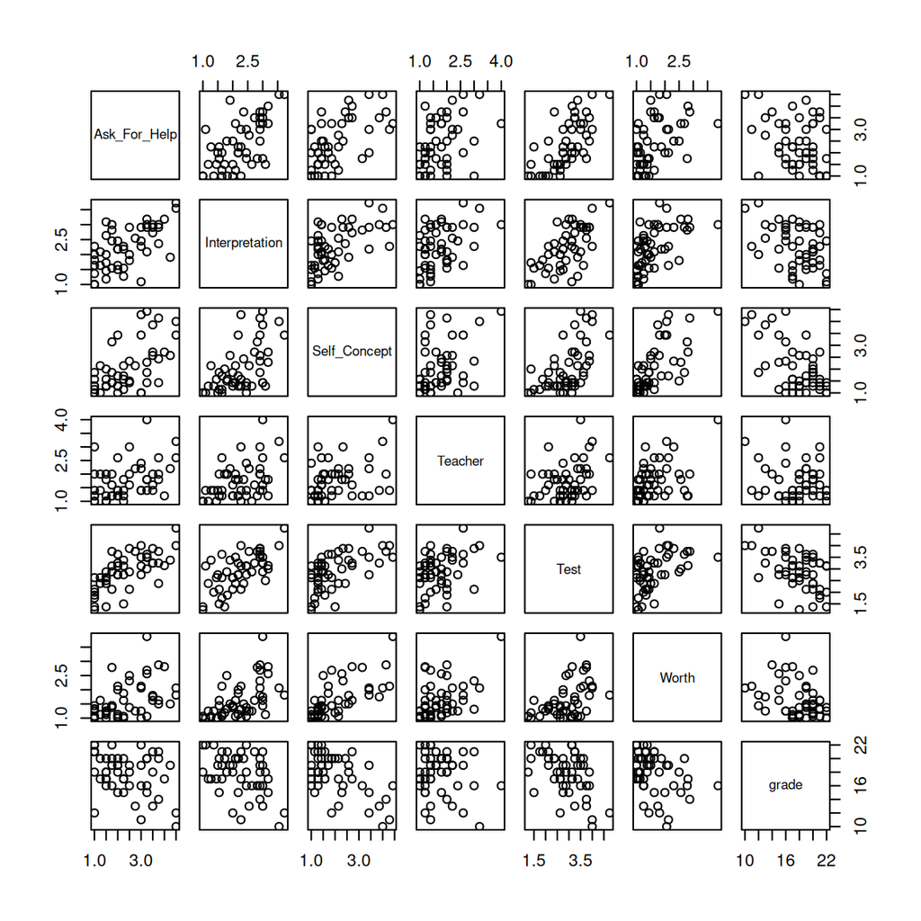

```r
subscale_wide |>
  pairs()
```

## Task 5: Run the multiple regression

Estimate the parameters for the multiple regression, with grade as the response variable and the subscale means as the predictors. This should be straightforward if your data are in the right format. Store the fitted model object in the variable `mod`.

Don’t forget to display your results using `summary()`, and take a moment to think about what all the numbers mean.

```r
mod <- lm(grade ~ Ask_For_Help + Interpretation + Self_Concept +
            Teacher + Test + Worth, subscale_wide)

summary(mod)
```

```
##
## Call:
## lm(formula = grade ~ Ask_For_Help + Interpretation + Self_Concept +
##     Teacher + Test + Worth, data = subscale_wide)
##
## Residuals:
##     Min      1Q  Median      3Q     Max
## -5.6127 -1.6329  0.0755  1.6458  4.8041
##
## Coefficients:
##                Estimate Std. Error t value Pr(>|t|)
## (Intercept)     22.3326     1.5704  14.221  < 2e-16 ***
## Ask_For_Help     0.3845     0.5227   0.736  0.46599
## Interpretation  -0.6382     0.7675  -0.831  0.41032
## Self_Concept    -1.8611     0.5806  -3.206  0.00254 **
## Teacher          0.6040     0.6394   0.945  0.35009
## Test            -0.8344     0.7129  -1.170  0.24827
## Worth            0.6492     0.8337   0.779  0.44044
## ---
## Signif. codes:  0 '***' 0.001 '**' 0.01 '*' 0.05 '.' 0.1 ' ' 1
##
## Residual standard error: 2.494 on 43 degrees of freedom
## Multiple R-squared:  0.4024, Adjusted R-squared:  0.319
## F-statistic: 4.826 on 6 and 43 DF,  p-value: 0.0007612
```

## Task 6: Which subscale is the ‘best’ predictor?

Is there one subscale that is more strongly linked to the final grade? The different subscales have different standard deviations, so you need to re-run the regression after standardizing the variables.

The variable `mod_z` should be a fitted model object (the result of a call to `lm()`).

The variable `name_of_best_predictor` should have the name of your predictor

```r
subscale_z <- subscale_wide |>
  mutate(afh_z = (Ask_For_Help - mean(Ask_For_Help)) / sd(Ask_For_Help),
         int_z = (Interpretation - mean(Interpretation)) / sd(Interpretation),
         sc_z = (Self_Concept - mean(Self_Concept)) / sd(Self_Concept),
         teacher_z = (Teacher - mean(Teacher)) / sd(Teacher),
         test_z = (Test - mean(Test)) / sd(Test),
         worth_z = (Worth - mean(Worth)) / sd(Worth))

mod_z <- lm(grade ~ afh_z + int_z + sc_z + teacher_z +
              test_z + worth_z, subscale_z)

summary(mod_z)
```

```
##
## Call:
## lm(formula = grade ~ afh_z + int_z + sc_z + teacher_z + test_z +
##     worth_z, data = subscale_z)
##
## Residuals:
##     Min      1Q  Median      3Q     Max
## -5.6127 -1.6329  0.0755  1.6458  4.8041
##
## Coefficients:
##             Estimate Std. Error t value Pr(>|t|)
## (Intercept)  17.7400     0.3527  50.293  < 2e-16 ***
## afh_z         0.3967     0.5393   0.736  0.46599
## int_z        -0.4405     0.5299  -0.831  0.41032
## sc_z         -1.8205     0.5679  -3.206  0.00254 **
## teacher_z     0.3973     0.4206   0.945  0.35009
## test_z       -0.6414     0.5480  -1.170  0.24827
## worth_z       0.4092     0.5255   0.779  0.44044
## ---
## Signif. codes:  0 '***' 0.001 '**' 0.01 '*' 0.05 '.' 0.1 ' ' 1
##
## Residual standard error: 2.494 on 43 degrees of freedom
## Multiple R-squared:  0.4024, Adjusted R-squared:  0.319
## F-statistic: 4.826 on 6 and 43 DF,  p-value: 0.0007612
```

```r
# you could just look at the output of summary()
# and decide on the 'best' predictor from that...
# that would be ok, but we can also use code to do it

# get the predictors excluding the intercept (element 1)
# negative value 'deselects' it
pred_coef <- coef(mod_z)[-1]

# get the index of the predictor with the largest absolute value
# better to use `dplyr::near()` instead of `==` when comparing 'doubles'.
# which of the elements equals the max element?
# `which()` returns a named (integer) index
best_index <- which(near(abs(pred_coef), max(abs(pred_coef))))

best_index
```

```
## sc_z
##    3
```

```r
# just get the name of the index
name_of_best_predictor <- names(best_index)
```

## Task 7: Compare models

Could we do just as well predicting grades from the ‘best’ predictor as we could by including all six subscale predictors? Do an analysis to test this. Store the result of the model comparison in `mod_compare`.

```r
## NB: you can use the standardized model if you wish

mod_sconly <- lm(grade ~ Self_Concept, data = subscale_wide)

mod_compare <- anova(mod_sconly, mod)

mod_compare
```

```
## Analysis of Variance Table
##
## Model 1: grade ~ Self_Concept
## Model 2: grade ~ Ask_For_Help + Interpretation + Self_Concept + Teacher +
##     Test + Worth
##   Res.Df    RSS Df Sum of Sq      F Pr(>F)
## 1     48 293.72
## 2     43 267.50  5    26.218 0.8429 0.5269
```

```r
## no evidence that the other subscales are predicting grade
## beyond self-concept!
```

# Validation

You’re finished! No need to alter anything in this final section. It is here to help ensure that all the assessment variables have been defined properly. Knit your file and check the resulting table below.

**Have all relevant variables been defined?** yes

[output not shown]

# References

Cruise, R. J., Cash, R. W., & Bolton, D. L. (1985). Development and validation of an instrument to measure statistical anxiety. *Paper presented at the proceedings of the American Statistical Association.*

Hanna, D., Shevlin, M., & Dempster, M. (2008). The structure of the statistics anxiety rating scale: A confirmatory factor analysis using UK psychology students. *Personality and Individual Differences*, *45*, 68-74.